# EL VUELO DE SIPRI

Docentes Interinos en Andalucía

Jose Ramón Hernández Galán

11/5/2020

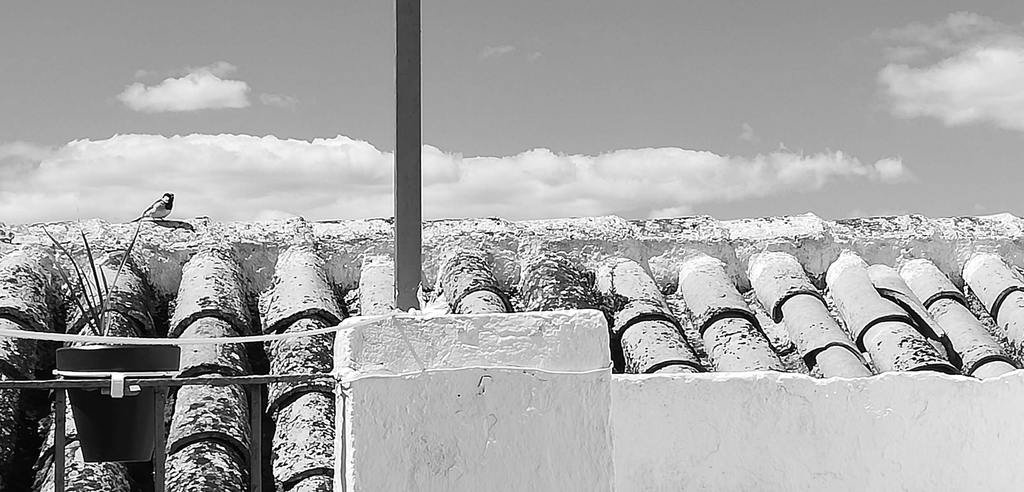

## Introducción

Si eres personal docente interino en Andalucía o aspiras a serlo no hace falta que te presente a Sipri. Si no es así, lo conocerás a lo largo de este artículo.

## SIPRI

SIPRI es el **SI**stema de **PR**ovisionamiento de **I**nterinos docentes de la Junta de Andalucía. La primera vez que oí hablar de él no sé porqué me sonó a un pájaro, igual en ese momento me vi influenciado por el logo del pájaro de Twiter que acompaña a las páginas de la Junta de Andalucía. De ahí el nombre de este trabajo.

En ocasiones, la vida del interino es similar a la de un pájaro, volando de un sitio a otro cubriendo las bajas del personal docente a lo largo y ancho de Andalucía. Es por esto que el título me pareció una buena metáfora de la vida interina.

## ¿Cúanto vuela SIPRI?

El siguiente gráfico muestra las plazas convocadas en SIPRI durante el curso 2019-2020.

Nuestra **serie de datos** empieza en Diciembre de 2019. Los datos se recogen periódicamente de la Junta de Andalucía.

Normalmente, hay **dos convocatorias por semana**. Comentar que después del COVID-19 solo hay un llamamiento por semana. En la (Figura 1) se muestran el total de las plazas convocadas en toda Andalucía para los distintos cuerpos (Maestros, Profesores, Catedráticos, etc.)

La **parada navideña**. Desde el inicio de Diciembre no hay más convocatorias hasta principios de Enero.

El parón del **COVID-19** se ve claramente en el hueco que queda en la parte derecha.

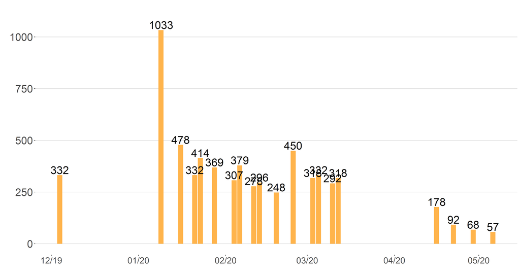

*Fig. 1: Plazas convocadas en SIPRI durante el curso.*

## ¿Cómo vuela SIPRI?

Como el número de plazas es abrimador vamos a separarlo por pcuerpos para tener una visión más clara de las convocatorias de losdistintos cuerpos. El siguiente gráfico (Fig. 2) muestra las plazas ofertadas en Sipri durante el curso 2019-2020 distribuidas por CUERPO.

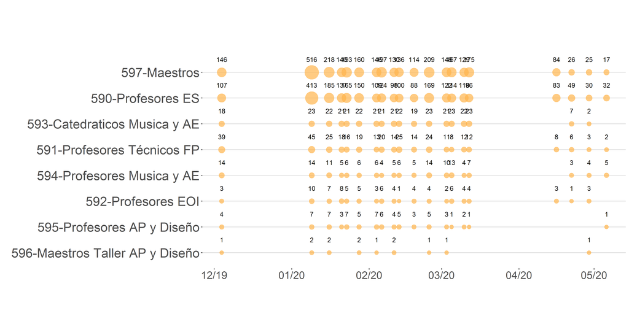

*Fig. 2: Plazas requeridas en SIPRI durante el curso.* Distribuidas por Cuerpo docente.

## ¿Donde vuela SIPRI?

Como el la comunidad de Andalucía tiene muchas provincias vamos mostrar las convoctorias por provincia para hacernos una idea donde se concentran las plazas convocadas

El siguiente gráfico (Fig. 3) muestra las plazas ofertadas en Sipri durante el curso 2019-2020 distribuidas por PROVINCIA.

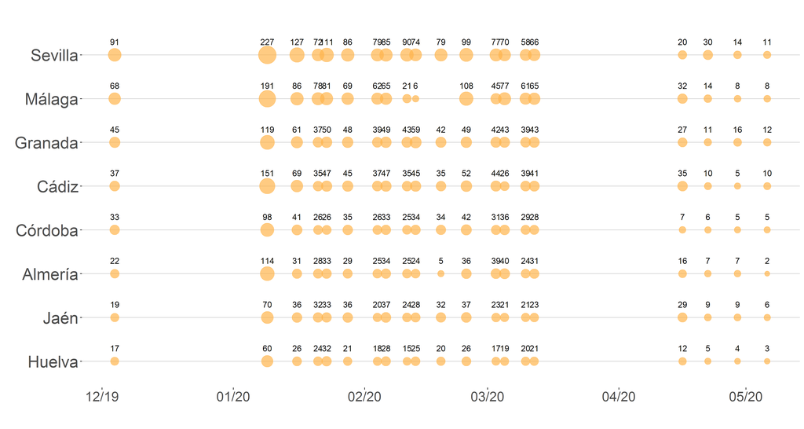

*Fig. 3: Plazas requeridas en SIPRI durante el curso.* Distribuidas por Provincia.

## ¿Cómo evolucionan las bolsas que utiliza Sipri?

La eterna pregunta del interino: ¿Cúando me convocarán para trabajar? ¿La bolsa se mueve rápido o lento? Pues bien, si observamos la evolución del orden de la última persona convocada nos da una idea sobre el movimiento de la bolsa.

En este gráfico se refleja el movimiento de la bolsa a través de los distintos llamamientos. Cada punto indica una convocatoria de dicho puesto y el orden de la última persona convocada. Esto nos indica como evoluciona la bolsa y el tamaño que puede tener.

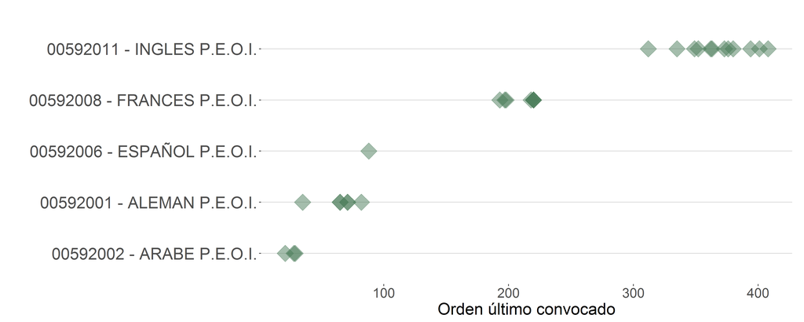

*Fig. 4: Orden en la bolsa del último convocado. Distribuido por Puesto. Incluye los puestos del cuerpo de profesores de la EOI.*

## Resumiendo

Para hacernos una idea de la distribución de plazas convocadas de los distintos cuerpos se generado el siguiente gráfico (Fig. 5) donde se ve claramente el ranking de convocatorias de los distintos cuerpos.

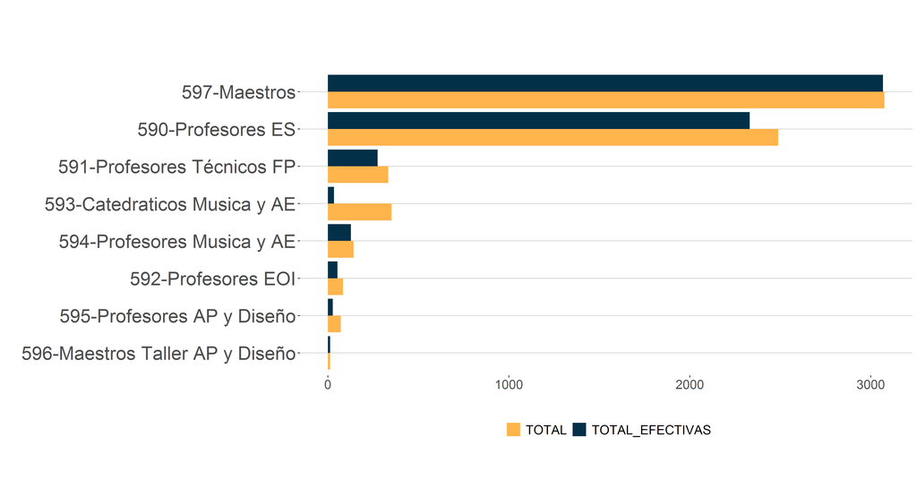

*Fig.5: Plazas totales requeridas en SIPRI. Distribuidas por Cuerpo docente.*

Parece que hay tantas plazas de catedráticos de Música como de profesores de FP. Vamos a explicar esta peculiaridad en el siguiente apartado.

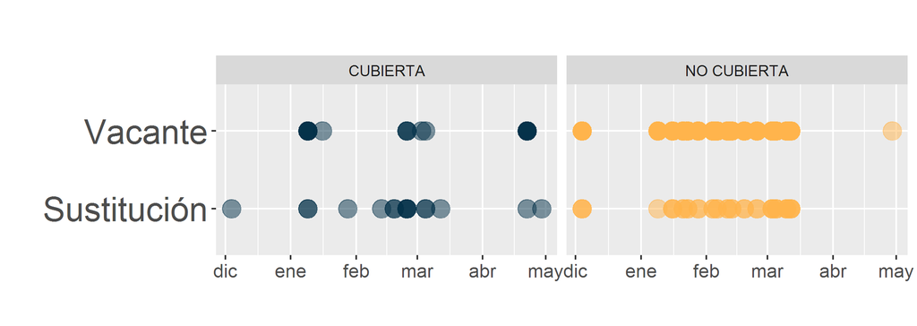

*Fig. 6: Plazas del Cuerpo de Catedráticos de Música y Artes Escénicas requeridas en SIPRI durante el curso.*

## Volando con Sipri

Si quieres personalizar la vista del vuelo de Sipri puedes utilizar nuestra aplicación web interactiva.

[**Web App interactiva**](https://jrlab.shinyapps.io/sipri)

Si necesitas una vista más profunda del vuelo de Sipri o tienes cualquier consulta puedes ponerte en contacto. En la sección de contacto podrás encontrar nuestra dirección.

## Referencias

Datos: recogidos de la Junta de Andalucía.

## Contacto

JRHG82. 2020. Puedes escribirme para cualquier aclaración a jrhg82@gmail.com

## Licencia

Este obra está bajo una [licencia de Creative Commons Reconocimiento-NoComercial-CompartirIgual 4.0 Internacional](http://creativecommons.org/licenses/by-nc-sa/4.0/).